# Final Section!

Practice Analyzing a Dataset

Your final exam is coming up - as a take home exam, you can expect it to be very similar to Quiz 1 (i.e., being asked to explore specific questions about datasets).

The way the final is formatted is the same kind of way that you would approach questions in your research - you have an interesting dataset and want to draw the most interesting conclusions from it. These are the most important skils to walk away from the class with!

So, today we're going to go through 2 things that I think are very important to take away from this class for your researchl:

1. Which tests to run (when you're asking certain questions about your data), and
2. How to interpret your output.

So, first we're going to briefly review some of the important points on how to interpret your output, starting out with mixed models. Then, we'll practice asking questions about a dataset (deciding which questions to ask, which tests we would run, and so on). And, we'll learn some new tricks that might be helpful in your future research along the way.

*** Interpreting Output: Mixed Models ***

Let's start out with mixed models, returing to our dataset `ex4.txt`.

Getting data set up:

```r
setwd("~/Downloads")
d0 <- read.table("ex4.txt", header = TRUE)
library(lme4)
```

```r
library(ggplot2)
library(plyr)

str(d0)
```

```
## 'data.frame':    30 obs. of  5 variables:
##  $ Observation: int  1 2 3 4 5 6 7 8 9 10 ...
##  $ Subject    : Factor w/ 5 levels "Faye","Jason",..: 3 3 3 3 3 3 5 5 5 5 ...
##  $ Task       : Factor w/ 2 levels "Cued","Free": 2 2 2 1 1 1 2 2 2 1 ...
##  $ Valence    : Factor w/ 3 levels "Neg","Neu","Pos": 1 2 3 1 2 3 1 2 3 1 ...
##  $ Recall     : int  8 9 5 7 9 10 12 13 14 16 ...
```

First, let's review interpreting the output of mixed models.

```r
rs.lmer0 = lmer(Recall ~ Task + Valence + (1 | Subject), d0)
summary(rs.lmer0)
```

```
## Linear mixed model fit by REML ['lmerMod']
## Formula: Recall ~ Task + Valence + (1 | Subject)
##    Data: d0
##
## REML criterion at convergence: 124
##
## Random effects:
##  Groups   Name        Variance Std.Dev.
##  Subject  (Intercept) 14.1     3.75
##  Residual              2.9     1.70
## Number of obs: 30, groups: Subject, 5
##
## Fixed effects:
##             Estimate Std. Error t value
## (Intercept)   12.000      1.789    6.71
## TaskFree      -2.000      0.622   -3.21
## ValenceNeu     1.100      0.762    1.44
## ValencePos     1.300      0.762    1.71
##
## Correlation of Fixed Effects:
##            (Intr) TaskFr ValncN
## TaskFree   -0.174
## ValenceNeu -0.213  0.000
## ValencePos -0.213  0.000  0.500
```

Note the variance. If there is significant variance around the random effect, then you can't be as confident about fixed effect (it will affect the *standard error* of the fixed effect).

To informally tell whether variance is appreciable, compare it to the residual for random error (then, for a formal test, compare models as in ANOVA).

In this additive model, our coefficients tell us about the differences between the groups collapsing across the other group.

The -2 estimate for “Task” is equal to the difference between Free and Cued, collapsing across Valence (12.8-10.8 = 2)

```r
aggregate(Recall ~ Task, d0, mean)
```

```
##   Task Recall
## 1 Cued   12.8
## 2 Free   10.8
```

The 1.1 is equal to the difference between the negative and neutral groups collapsing across Task (12.1-11 = 1.1), same with 1.3 as the difference between the positive and negative groups (12.3 - 11.0 = 1.3).

```r
aggregate(Recall ~ Valence, d0, mean)
```

```
##   Valence Recall
## 1     Neg   11.0
## 2     Neu   12.1
## 3     Pos   12.3
```

Now let's take a look at the interactive model.

```r
rs.lmer1 = lmer(Recall ~ Task * Valence + (1 | Subject), d0)
summary(rs.lmer1)
```

```
## Linear mixed model fit by REML ['lmerMod']
## Formula: Recall ~ Task * Valence + (1 | Subject)
##    Data: d0
##
## REML criterion at convergence: 118.4
##
## Random effects:
##  Groups   Name        Variance Std.Dev.
##  Subject  (Intercept) 14.03    3.75
##  Residual              3.12    1.77
## Number of obs: 30, groups: Subject, 5
##
## Fixed effects:
##                     Estimate Std. Error t value
## (Intercept)            11.80       1.85    6.37
## TaskFree               -1.60       1.12   -1.43
## ValenceNeu              1.20       1.12    1.07
## ValencePos              1.80       1.12    1.61
## TaskFree:ValenceNeu    -0.20       1.58   -0.13
## TaskFree:ValencePos    -1.00       1.58   -0.63
##
## Correlation of Fixed Effects:
##             (Intr) TaskFr ValncN VlncPs TsF:VN
## TaskFree    -0.302
## ValenceNeu  -0.302  0.500
## ValencePos  -0.302  0.500  0.500
## TskFr:VlncN  0.213 -0.707 -0.707 -0.354
## TskFr:VlncP  0.213 -0.707 -0.354 -0.707  0.500
```

With interactive models, it helps to think of them in terms of your regression equation.

Y = b0 + (b1 * Task) + (b2 * Valence1) + (b3 * Valence 2) + (b4 * Task * Valence1) + (b5 * Task * Valence2)

We use the values from our contrasts and multiply them by the slopes from our model.

```r
contrasts(d0$Task)
```

```
##      Free
## Cued    0
## Free    1
```

```r
contrasts(d0$Valence)
```

```
##     Neu Pos
## Neg   0   0
## Neu   1   0
## Pos   0   1
```

So for a person in the Free Recall / Negative Valence Condition:

```r
11.8 + (-1.6 * 1) + (1.2 * 0) + (1.8 * 0) + (-0.2 * 1 * 0) + (-1 * 1 * 0)
```

```
## [1] 10.2
```

```r
aggregate(Recall ~ Valence + Task, d0, mean)
```

```
##   Valence Task Recall
## 1     Neg Cued   11.8
## 2     Neu Cued   13.0
## 3     Pos Cued   13.6
## 4     Neg Free   10.2
## 5     Neu Free   11.2
## 6     Pos Free   11.0
```

And for a person in the Free Recall / Positive Valence Condition:

Y = 11.8 + (-1.6 * 1) + (1.2 * 0) + (1.8 * 1) + (-.2 * 1 * 0) + (-1.0 * 1 * 1)

```r
11.8 + (-1.6 * 1) + (1.2 * 0) + (1.8 * 1) + (-0.2 * 1 * 0) + (-1 * 1 * 1)
```

```
## [1] 11
```

Let's talk briefly about parameters and degrees of freedom. Last time we discussed wanting to have greater than 0 degrees of freedom, or your model is “overfitted” or “overparameterized” and not useful for prediction.

Degrees of freedom = the difference in the number of parameters your model is estimating.

For random effects, parameters can be either correlations, or random variance estimates.

We can see the difference in degrees of freedom using this ANOVA test.

How would we compare models? Different fixed effects structure (but nested), same random effects: *ML deviance, REML = FALSE*

```r
anova(rs.lmer0, rs.lmer1)
```

```
## Data: d0
## Models:
## rs.lmer0: Recall ~ Task + Valence + (1 | Subject)
## rs.lmer1: Recall ~ Task * Valence + (1 | Subject)
##          Df AIC BIC logLik deviance Chisq Chi Df Pr(>Chisq)
## rs.lmer0  6 142 150  -64.9      130
## rs.lmer1  8 145 156  -64.6      129  0.55      2       0.76
```

Note the degrees of freedom, and the difference in the number of parameters.

An example with changing random effects. Let's add in a random slope for Task, making the random effects more complex.

```r
rs.lmer0a = lmer(Recall ~ Task + Valence + (Task | Subject), d0)
summary(rs.lmer0a)
```

```
## Linear mixed model fit by REML ['lmerMod']
## Formula: Recall ~ Task + Valence + (Task | Subject)
##    Data: d0
##
## REML criterion at convergence: 120.1
##
## Random effects:
##  Groups   Name        Variance Std.Dev. Corr
##  Subject  (Intercept) 19.62    4.43
##           TaskFree     1.78    1.34     -1.00
##  Residual              2.41    1.55
## Number of obs: 30, groups: Subject, 5
##
## Fixed effects:
##             Estimate Std. Error t value
## (Intercept)   12.000      2.060    5.82
## TaskFree      -2.000      0.824   -2.43
## ValenceNeu     1.100      0.694    1.58
## ValencePos     1.300      0.694    1.87
##
## Correlation of Fixed Effects:
##            (Intr) TaskFr ValncN
## TaskFree   -0.792
## ValenceNeu -0.168  0.000
## ValencePos -0.168  0.000  0.500
```

Comparing the models - same fixed effects structure, different random effects structure: *REML deviance*

```r
rs.lmer0 = lmer(Recall ~ Task + Valence + (1 | Subject), d0, REML = TRUE)
rs.lmer0a = lmer(Recall ~ Task + Valence + (Task | Subject), d0, REML = TRUE)
anova(rs.lmer0, rs.lmer0a)
```

```
## Data: d0
## Models:
## rs.lmer0: Recall ~ Task + Valence + (1 | Subject)
## rs.lmer0a: Recall ~ Task + Valence + (Task | Subject)
##           Df AIC BIC logLik deviance Chisq Chi Df Pr(>Chisq)
## rs.lmer0   6 142 150  -64.9      130
## rs.lmer0a  8 141 152  -62.7      125  4.49      2       0.11
```

```r
summary(rs.lmer0)
```

```
## Linear mixed model fit by REML ['lmerMod']
## Formula: Recall ~ Task + Valence + (1 | Subject)
##    Data: d0
##
## REML criterion at convergence: 124
##
## Random effects:
##  Groups   Name        Variance Std.Dev.
##  Subject  (Intercept) 14.1     3.75
##  Residual              2.9     1.70
## Number of obs: 30, groups: Subject, 5
##
## Fixed effects:
##             Estimate Std. Error t value
## (Intercept)   12.000      1.789    6.71
## TaskFree      -2.000      0.622   -3.21
## ValenceNeu     1.100      0.762    1.44
## ValencePos     1.300      0.762    1.71
##
## Correlation of Fixed Effects:
##            (Intr) TaskFr ValncN
## TaskFree   -0.174
## ValenceNeu -0.213  0.000
## ValencePos -0.213  0.000  0.500
```

```r
summary(rs.lmer0a)
```

```
## Linear mixed model fit by REML ['lmerMod']
## Formula: Recall ~ Task + Valence + (Task | Subject)
##    Data: d0
##
## REML criterion at convergence: 120.1
##
## Random effects:
##  Groups   Name        Variance Std.Dev. Corr
##  Subject  (Intercept) 19.62    4.43
##           TaskFree     1.78    1.34     -1.00
##  Residual              2.41    1.55
## Number of obs: 30, groups: Subject, 5
##
## Fixed effects:
##             Estimate Std. Error t value
## (Intercept)   12.000      2.060    5.82
## TaskFree      -2.000      0.824   -2.43
## ValenceNeu     1.100      0.694    1.58
## ValencePos     1.300      0.694    1.87
##
## Correlation of Fixed Effects:
##            (Intr) TaskFr ValncN
## TaskFree   -0.792
## ValenceNeu -0.168  0.000
## ValencePos -0.168  0.000  0.500
```

*** Review of Data Analysis ***

In order to review some of the important take-aways from the class, we're going to conveninetly randomly generate a dataset.

Let's say that we're interested in what predicts life satisfaction. Does “living in the past, present, or the future” make you feel more or less happy with your current life? We design a manipulation to make people focus either on the present (write about what your life is like now), on the past (write about what your life was like 5 years ago), or on the future (write about what your life will be five years from now).

We get 108 participants total for our study. So we can check whether people completed the survey correctly, we measure the number of words they wrote during the two minute prompt.

```r
subid <- c(1:108)
cond <- rep(c("future", "past", "present"), each = 36)
length <- rep(c(35, 73:92, 145, 150, 151, 168, 203, 304), 4)
```

After we have people write a short, 2-minute passage with either of these three prompts, we ask people to fill out a scale measuring their subjective well-being (e.g., “In most ways, my life is close to my ideal,” 1 = *not at all*, 7 = *completely*).

```r
r1 <- round(rnorm(36, mean = 4.76, sd = 1.09), digits = 0)  # rounding, no decimals
r2 <- round(rnorm(36, mean = 5.06, sd = 1.17), digits = 0)
r3 <- round(rnorm(36, mean = 3.23, sd = 0.89), digits = 0)
lifesat <- c(r1, r2, r3)
```

We also think some demographic variables, like gender, age, and income, might influence happiness, so we ask participants for those demographic variables.

```r
gender <- sample(c("male", "female", NA), 108, replace = TRUE, prob = c(0.48,
    0.48, 0.02))  # Since no dataset is perfect we'll randomly insert some missing data into our dataframe.

age <- sample(c(18:40, NA), 108, replace = TRUE)

income = sample(c(seq(0, 30000, by = 1000), seq(0, 150000, by = 1000)), 108,
    replace = TRUE)
```

Let's create our initial dataset.

```r
d <- data.frame(subid, age, gender, income, cond, length, lifesat)
```

One week later, we send out a short online survey and ask participants again to rate their subjective well-being, to see if our manipulation has any lasting effects. Some of the participants unfortunately don't respond, so we only have 95 participants who do.

```r
id <- sample(c(1:108), 95, replace = FALSE)
lifesat2 <- round(runif(95, 1, 7), digits = 0)

f <- data.frame(id, lifesat2)
```

Let's make sure our variables are in the right format.

```r
str(d)
```

```
## 'data.frame':    108 obs. of  7 variables:
##  $ subid  : int  1 2 3 4 5 6 7 8 9 10 ...
##  $ age    : int  33 19 24 22 38 37 21 NA 18 19 ...
##  $ gender : Factor w/ 2 levels "female","male": 2 2 1 1 2 2 2 2 2 2 ...
##  $ income : num  123000 94000 90000 63000 5000 115000 64000 78000 29000 22000 ...
##  $ cond   : Factor w/ 3 levels "future","past",..: 1 1 1 1 1 1 1 1 1 1 ...
##  $ length : num  35 73 74 75 76 77 78 79 80 81 ...
##  $ lifesat: num  5 7 6 4 5 5 3 4 6 4 ...
```

```r
d$subid <- factor(d$subid)  # making sure to change subid!

str(f)
```

```
## 'data.frame':    95 obs. of  2 variables:
##  $ id      : int  48 81 44 51 55 90 47 22 73 93 ...
##  $ lifesat2: num  5 4 2 4 4 3 2 3 6 3 ...
```

```r
f$id <- factor(f$id)
```

Alright, now that we've “collected” our data, let's start analyzing it.

First - how do we merge our two data frames, so that we can look at participants who answered our follow up survey?

Answer: `merge()` function!

```r
`?`(merge)

m <- merge(d, f, by.x = "subid", by.y = "id")
head(m)
```

```
##   subid age gender income    cond length lifesat lifesat2
## 1    10  19   male  22000  future     81       4        6
## 2   100  29   male 132000 present     90       4        4
## 3   101  31   male 139000 present     91       2        5
## 4   103  23 female  21000 present    145       3        1
## 5   104  19 female  19000 present    150       4        3
## 6   106  22   male 122000 present    168       5        2
```

```r
summary(m)
```

```
##      subid         age          gender       income            cond
##  2      : 1   Min.   :18.0   female:43   Min.   :  1000   future :31
##  3      : 1   1st Qu.:22.5   male  :51   1st Qu.: 19000   past   :35
##  4      : 1   Median :26.0   NA's  : 1   Median : 39000   present:29
##  5      : 1   Mean   :27.3               Mean   : 55105
##  6      : 1   3rd Qu.:31.0               3rd Qu.: 89500
##  7      : 1   Max.   :40.0               Max.   :149000
##  (Other):89   NA's   :4
##      length         lifesat       lifesat2
##  Min.   : 35.0   Min.   :2.0   Min.   :1.00
##  1st Qu.: 78.0   1st Qu.:3.0   1st Qu.:3.00
##  Median : 84.0   Median :4.0   Median :3.00
##  Mean   :102.8   Mean   :4.4   Mean   :3.64
##  3rd Qu.: 90.5   3rd Qu.:5.0   3rd Qu.:5.00
##  Max.   :304.0   Max.   :7.0   Max.   :7.00
##
```

This is cool, but let's say that we don't want to discard our data from the people who didn't fill out the follow up survey. We can just add the argument `all = TRUE` and have NAs added in for our missing data from the follow up survey.

```r
m <- merge(d, f, by.x = "subid", by.y = "id", all.x = TRUE)
head(m)
```

```
##   subid age gender income   cond length lifesat lifesat2
## 1     1  33   male 123000 future     35       5       NA
## 2     2  19   male  94000 future     73       7        1
## 3     3  24 female  90000 future     74       6        3
## 4     4  22 female  63000 future     75       4        3
## 5     5  38   male   5000 future     76       5        2
## 6     6  37   male 115000 future     77       5        3
```

```r
summary(m)
```

```
##      subid          age          gender       income            cond
##  1      :  1   Min.   :18.0   female:51   Min.   :  1000   future :36
##  2      :  1   1st Qu.:22.0   male  :54   1st Qu.: 19750   past   :36
##  3      :  1   Median :26.0   NA's  : 3   Median : 48000   present:36
##  4      :  1   Mean   :27.1               Mean   : 59167
##  5      :  1   3rd Qu.:31.0               3rd Qu.: 92500
##  6      :  1   Max.   :40.0               Max.   :149000
##  (Other):102   NA's   :6
##      length       lifesat        lifesat2
##  Min.   : 35   Min.   :2.00   Min.   :1.00
##  1st Qu.: 78   1st Qu.:3.00   1st Qu.:3.00
##  Median : 85   Median :4.00   Median :3.00
##  Mean   :104   Mean   :4.37   Mean   :3.64
##  3rd Qu.: 92   3rd Qu.:5.00   3rd Qu.:5.00
##  Max.   :304   Max.   :7.00   Max.   :7.00
##                               NA's   :13
```

## Skill 1: Basic plotting and demographics

Report some basic statistics about your sample.

```r
mean(m$age)
```

```
## [1] NA
```

```r
# Remember to try removing NAs if this ever doesn't work!
mean(m$age, na.rm = TRUE)
```

```
## [1] 27.05
```

```r
table(m$gender)
```

```
##
## female   male
##     51     54
```

```r
summary(m$gender)  # summary function is a handy way to check for missing data, don't necessarily see with table
```

```
## female   male   NA's
##     51     54      3
```

```r
# T test of age and gender
summary(lm(age ~ gender, m))
```

```
##
## Call:
## lm(formula = age ~ gender, data = m)
##
## Residuals:
##    Min     1Q Median     3Q    Max
## -10.10  -4.96  -1.46   4.90  14.04
##
## Coefficients:
##             Estimate Std. Error t value Pr(>|t|)
## (Intercept)   25.960      0.863   30.09   <2e-16 ***
## gendermale     2.140      1.220    1.75    0.083 .
## ---
## Signif. codes:  0 '***' 0.001 '**' 0.01 '*' 0.05 '.' 0.1 ' ' 1
##
## Residual standard error: 6.1 on 98 degrees of freedom
##   (8 observations deleted due to missingness)
## Multiple R-squared:  0.0304, Adjusted R-squared:  0.0205
## F-statistic: 3.08 on 1 and 98 DF,  p-value: 0.0826
```

```r
t.test(m$age[m$gender == "male"], m$age[m$gender == "female"])
```

```
##
##  Welch Two Sample t-test
##
## data:  m$age[m$gender == "male"] and m$age[m$gender == "female"]
## t = 1.754, df = 97.97, p-value = 0.08262
## alternative hypothesis: true difference in means is not equal to 0
## 95 percent confidence interval:
##  -0.2817  4.5617
## sample estimates:
## mean of x mean of y
##     28.10     25.96
```

```r
aggregate(age ~ gender, m, mean)
```

```
##   gender   age
## 1 female 25.96
## 2   male 28.10
```

First, let's find a nice way of visualizing the data that lets us check if everything looks normal, and gives us a preliminary look at where the means lie.

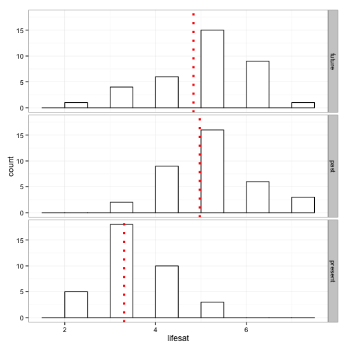

```r
sum <- ddply(m, "cond", summarise, rating.mean = mean(lifesat, na.rm = TRUE))

ggplot(m, aes(x = lifesat)) + geom_histogram(binwidth = 0.5, colour = "black",
    fill = "white") + facet_grid(cond ~ .) + geom_vline(data = sum, aes(xintercept = rating.mean),
    linetype = "dotted", size = 1.5, colour = "red") + theme_bw()
```

## Skill 2: Checking for random assignment.

Were people equally assigned to condition, according to gender, age, and income?

```r
t1 <- table(m$gender, m$cond)
print(t1)
```

```
##
##          future past present
##   female     13   19      19
##   male       21   16      17
```

```r
chisq.test(t1)
```

```
##
##  Pearson's Chi-squared test
##
## data:  t1
## X-squared = 2.167, df = 2, p-value = 0.3385
```

```r
summary(t1)
```

```
## Number of cases in table: 105
## Number of factors: 2
## Test for independence of all factors:
##  Chisq = 2.2, df = 2, p-value = 0.3
```

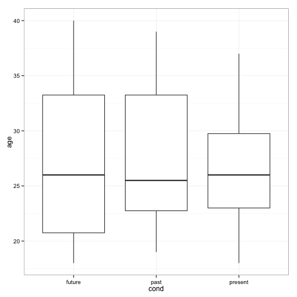

```r
qplot(cond, age, geom = "boxplot", data = m) + theme_bw()
```

```r
summary(lm(age ~ cond))
```

```
##
## Call:
## lm(formula = age ~ cond)
##
## Residuals:
##    Min     1Q Median     3Q    Max
##  -9.09  -5.09  -1.09   4.65  12.91
##
## Coefficients:
##             Estimate Std. Error t value Pr(>|t|)
## (Intercept)   27.094      1.114   24.31   <2e-16 ***
## condpast       0.573      1.532    0.37     0.71
## condpresent   -0.741      1.553   -0.48     0.63
## ---
## Signif. codes:  0 '***' 0.001 '**' 0.01 '*' 0.05 '.' 0.1 ' ' 1
##
## Residual standard error: 6.3 on 99 degrees of freedom
##   (6 observations deleted due to missingness)
## Multiple R-squared:  0.00764,    Adjusted R-squared:  -0.0124
## F-statistic: 0.381 on 2 and 99 DF,  p-value: 0.684
```

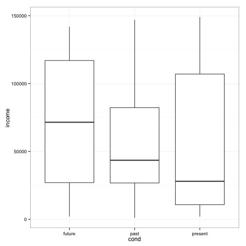

```r
qplot(cond, income, geom = "boxplot", data = m) + theme_bw()
```

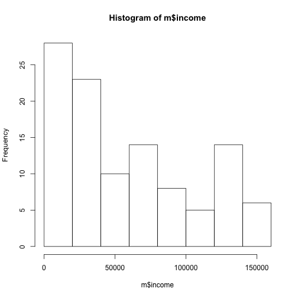

```r
# normally income data tends to be skewed - let's take a look at our data
# just to make sure we know what's going on
hist(m$income)
```

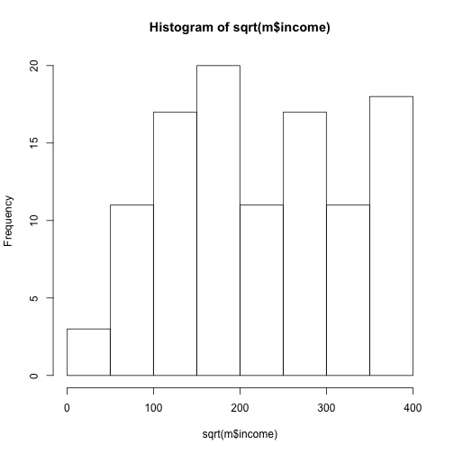

```r
hist(sqrt(m$income))
```

```r
summary(lm(income ~ cond, m))
```

```
##
## Call:
## lm(formula = income ~ cond, data = m)
##
## Residuals:
##    Min     1Q Median     3Q    Max
## -68389 -39139 -10389  38306  95583
##
## Coefficients:
##             Estimate Std. Error t value Pr(>|t|)
## (Intercept)    70389       7605    9.26  2.9e-15 ***
## condpast      -16694      10755   -1.55     0.12
## condpresent   -16972      10755   -1.58     0.12
## ---
## Signif. codes:  0 '***' 0.001 '**' 0.01 '*' 0.05 '.' 0.1 ' ' 1
##
## Residual standard error: 45600 on 105 degrees of freedom
## Multiple R-squared:  0.0302, Adjusted R-squared:  0.0117
## F-statistic: 1.63 on 2 and 105 DF,  p-value: 0.2
```

```r
summary(lm(sqrt(income) ~ cond, m))
```

```
##
## Call:
## lm(formula = sqrt(income) ~ cond, data = m)
##
## Residuals:
##     Min      1Q  Median      3Q     Max
## -202.86  -80.77   -4.06   86.84  184.94
##
## Coefficients:
##             Estimate Std. Error t value Pr(>|t|)
## (Intercept)    247.6       16.6   14.92   <2e-16 ***
## condpast       -31.1       23.5   -1.33     0.19
## condpresent    -46.5       23.5   -1.98     0.05 .
## ---
## Signif. codes:  0 '***' 0.001 '**' 0.01 '*' 0.05 '.' 0.1 ' ' 1
##
## Residual standard error: 99.6 on 105 degrees of freedom
## Multiple R-squared:  0.0374, Adjusted R-squared:  0.0191
## F-statistic: 2.04 on 2 and 105 DF,  p-value: 0.135
```

## Skill 3: Omitting unusual cases

Would you remove any participants based off of length? Did length differ by condition?

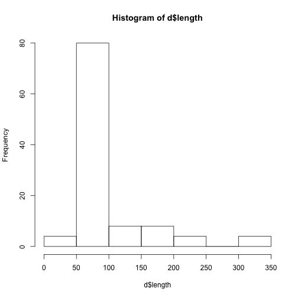

```r
hist(d$length)
```

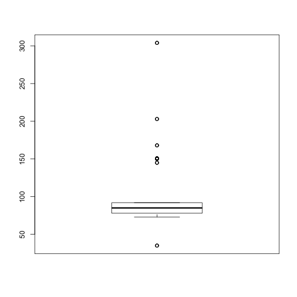

```r
boxplot(d$length)
```

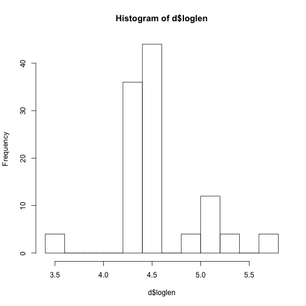

```r
# very positively skewed, so we'll take the log

d$loglen <- log(d$length)
hist(d$loglen)
```

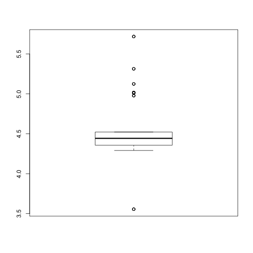

```r
boxplot(d$loglen)
```

```r
# what if transformations don't fix variables?  Can also just make the
# variable into a categorical variable!

median(d$length)
```

```
## [1] 85
```

```r
d$lencat <- ifelse(d$length < 85, c("short"), c("long"))
table(d$lencat)
```

```
##
##  long short
##    56    52
```

```r
t1 <- table(d$cond, d$lencat)
print(t1)
```

```
##
##           long short
##   future    14    22
##   past      19    17
##   present   23    13
```

```r
chisq.test(t1)
```

```
##
##  Pearson's Chi-squared test
##
## data:  t1
## X-squared = 4.525, df = 2, p-value = 0.1041
```

Looking at proportions can give you a good idea of what's going on in a chi square test.

```r
prop.table(t1)
```

```
##
##             long  short
##   future  0.1296 0.2037
##   past    0.1759 0.1574
##   present 0.2130 0.1204
```

Identifying outliers on the subjective well-being scale, by condition.

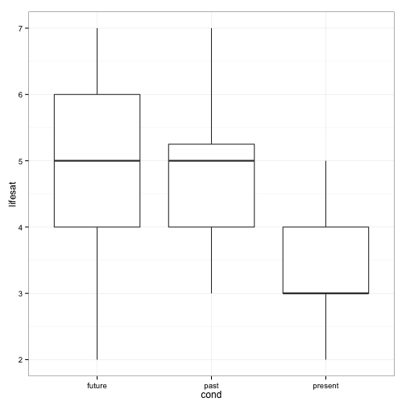

```r
qplot(cond, lifesat, geom = "boxplot", data = m) + theme_bw()
```

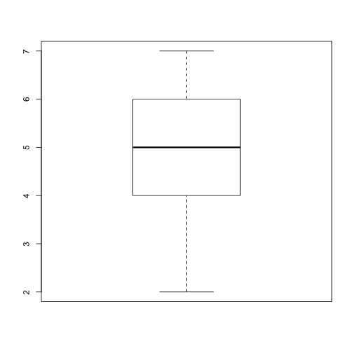

```r
bp1 <- boxplot(m$lifesat[m$cond == "future"])
```

```r
bp1$out
```

```
## numeric(0)
```

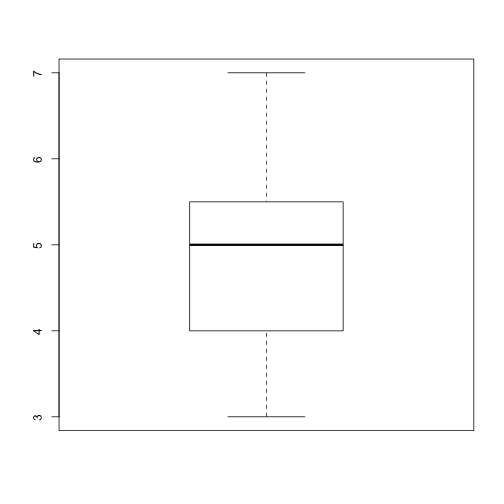

```r
# subset(m, lifesat == & cond == 'future')

bp2 <- boxplot(m$lifesat[m$cond == "past"])
```

```r
bp2$out
```

```
## numeric(0)
```

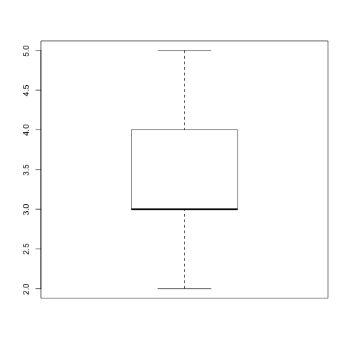

```r
# subset(m, lifesat == & cond == 'past')

bp3 <- boxplot(m$lifesat[m$cond == "present"])
```

```r
bp3$out
```

```
## numeric(0)
```

```r
# subset(m, lifesat == & cond == 'present')
```

Does condition predict life satisfaction?

```r
summary(lm(lifesat[-c()] ~ cond[-c()], m))
```

[output not shown]

Let's say that we had correctly predicted that people in the present would feel worse than people in the past or future. *Make sure to code the contrasts accordingly!*

First, let's visualize our data by gender.

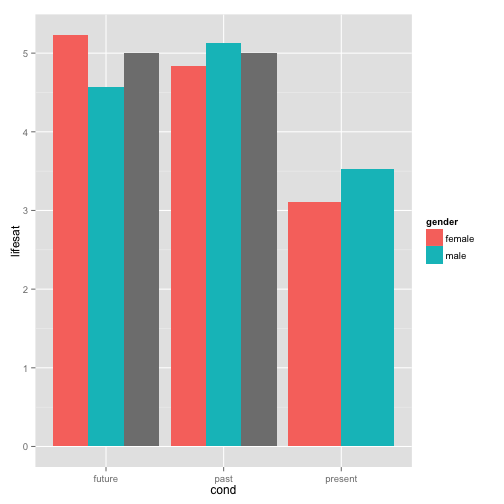

```r
qplot(cond, lifesat, data = m, geom = "bar", position = "dodge", fill = gender,
    stat = "summary", fun.y = "mean")  # note that the gray bars are NAs
```

What things should I keep in mind as I'm creating models?

Testing for interactions: making sure to scale variables that are not categorical!

```r
summary(lm(lifesat ~ cond * scale(age, scale = FALSE), m))
```

```
##
## Call:
## lm(formula = lifesat ~ cond * scale(age, scale = FALSE), data = m)
##
## Residuals:
##     Min      1Q  Median      3Q     Max
## -2.8261 -0.6359 -0.0245  0.7426  2.3139
##
## Coefficients:
##                                       Estimate Std. Error t value Pr(>|t|)
## (Intercept)                             4.8740     0.1773   27.50  < 2e-16
## condpast                                0.0848     0.2442    0.35     0.73
## condpresent                            -1.6083     0.2481   -6.48  3.9e-09
## scale(age, scale = FALSE)               0.0233     0.0244    0.96     0.34
## condpast:scale(age, scale = FALSE)     -0.0015     0.0362   -0.04     0.97
## condpresent:scale(age, scale = FALSE)  -0.0643     0.0423   -1.52     0.13
##
## (Intercept)                           ***
## condpast
## condpresent                           ***
## scale(age, scale = FALSE)
## condpast:scale(age, scale = FALSE)
## condpresent:scale(age, scale = FALSE)
## ---
## Signif. codes:  0 '***' 0.001 '**' 0.01 '*' 0.05 '.' 0.1 ' ' 1
##
## Residual standard error: 1 on 96 degrees of freedom
##   (6 observations deleted due to missingness)
## Multiple R-squared:  0.397,  Adjusted R-squared:  0.366
## F-statistic: 12.6 on 5 and 96 DF,  p-value: 1.94e-09
```

```r
summary(lm(lifesat ~ cond * scale(income, scale = FALSE), m))
```

```
##
## Call:
## lm(formula = lifesat ~ cond * scale(income, scale = FALSE), data = m)
##
## Residuals:
##     Min      1Q  Median      3Q     Max
## -2.8268 -0.6761  0.0355  0.7666  2.1689
##
## Coefficients:
##                                           Estimate Std. Error t value
## (Intercept)                               4.83e+00   1.71e-01   28.33
## condpast                                  1.41e-01   2.39e-01    0.59
## condpresent                              -1.51e+00   2.38e-01   -6.33
## scale(income, scale = FALSE)             -9.38e-08   3.72e-06   -0.03
## condpast:scale(income, scale = FALSE)     6.05e-07   5.85e-06    0.10
## condpresent:scale(income, scale = FALSE)  3.42e-06   4.88e-06    0.70
##                                          Pr(>|t|)
## (Intercept)                               < 2e-16 ***
## condpast                                     0.56
## condpresent                               6.5e-09 ***
## scale(income, scale = FALSE)                 0.98
## condpast:scale(income, scale = FALSE)        0.92
## condpresent:scale(income, scale = FALSE)     0.48
## ---
## Signif. codes:  0 '***' 0.001 '**' 0.01 '*' 0.05 '.' 0.1 ' ' 1
##
## Residual standard error: 0.993 on 102 degrees of freedom
## Multiple R-squared:  0.384,  Adjusted R-squared:  0.354
## F-statistic: 12.7 on 5 and 102 DF,  p-value: 1.3e-09
```

Checking for quadratic components:

```r
summary(lm(lifesat ~ cond * poly(income, 2)))
```

```
##
## Call:
## lm(formula = lifesat ~ cond * poly(income, 2))
##
## Residuals:
##     Min      1Q  Median      3Q     Max
## -2.6304 -0.5753  0.0078  0.6939  2.0817
##
## Coefficients:
##                              Estimate Std. Error t value Pr(>|t|)
## (Intercept)                    4.8127     0.1742   27.63  < 2e-16 ***
## condpast                       0.0892     0.2545    0.35     0.73
## condpresent                   -1.4410     0.2594   -5.55  2.3e-07 ***
## poly(income, 2)1               0.0456     1.7829    0.03     0.98
## poly(income, 2)2              -1.3158     1.7529   -0.75     0.45
## condpast:poly(income, 2)1     -0.3927     2.8693   -0.14     0.89
## condpresent:poly(income, 2)1   1.6684     2.3490    0.71     0.48
## condpast:poly(income, 2)2     -0.6492     2.7335   -0.24     0.81
## condpresent:poly(income, 2)2   0.3836     2.5659    0.15     0.88
## ---
## Signif. codes:  0 '***' 0.001 '**' 0.01 '*' 0.05 '.' 0.1 ' ' 1
##
## Residual standard error: 0.999 on 99 degrees of freedom
## Multiple R-squared:  0.394,  Adjusted R-squared:  0.346
## F-statistic: 8.06 on 8 and 99 DF,  p-value: 2.52e-08
```

# Skill 4: Controlling for variables and comparing models.

```r
m1 <- na.omit(m)  # otherwise errors because of missing data

mod1 <- lm(lifesat ~ cond, m1)
mod2 <- lm(lifesat ~ cond + age, m1)
mod3 <- lm(lifesat ~ cond + age + income, m1)
anova(mod1, mod2, mod3)
```

```
## Analysis of Variance Table
##
## Model 1: lifesat ~ cond
## Model 2: lifesat ~ cond + age
## Model 3: lifesat ~ cond + age + income
##   Res.Df  RSS Df Sum of Sq    F Pr(>F)
## 1     87 88.3
## 2     86 88.0  1     0.249 0.24   0.62
## 3     85 87.6  1     0.444 0.43   0.51
```

```r
mod2a <- lm(lifesat ~ cond + income, m1)

anova(mod1, mod2, mod2a, mod3)  # doesn't work!
```

```
## Analysis of Variance Table
##
## Model 1: lifesat ~ cond
## Model 2: lifesat ~ cond + age
## Model 3: lifesat ~ cond + income
## Model 4: lifesat ~ cond + age + income
##   Res.Df  RSS Df Sum of Sq    F Pr(>F)
## 1     87 88.3
## 2     86 88.0  1     0.249 0.24   0.62
## 3     86 87.8  0     0.268
## 4     85 87.6  1     0.176 0.17   0.68
```

```r
anova(mod1, mod2a, mod3)
```

```
## Analysis of Variance Table
##
## Model 1: lifesat ~ cond
## Model 2: lifesat ~ cond + income
## Model 3: lifesat ~ cond + age + income
##   Res.Df  RSS Df Sum of Sq    F Pr(>F)
## 1     87 88.3
## 2     86 87.8  1     0.517 0.50   0.48
## 3     85 87.6  1     0.176 0.17   0.68
```

Practice answering some questions:

Were there differences that persisted in life satisfaction?

Did people change in their levels of happiness over time?

For the final: 1. Make sure your variables are in the format that you would want them in (factor, numeric, etc.) 2. Start by visualizing data (helps you decide your next step!). Look at means, for potential interactions or quadratic components, variability by subject (e.g., with ggplot) 3. Decide what test you should use to answer the question at hand (mixed models? t-tests? regressions (logistic or linear)?) 4. When multiple possible models (e.g., controlling for variables, interactive vs. additive, poly components), compare models to help justify your model choice (e.g., using ANOVA)

** GOOD LUCK! **